# mdcBiscNcrmp

Lexie Sturm – lexie.sturm@noaa.gov

2024-08-12

# About this document

All analyses were performed in R version 4.4.1. This is the code that is examining NCRMP surveys within Miami-Dade County. *# Basic setup of R environment* ## Loading required packages For the following analyses we will require the use of multiple different R packages, we can use the package *pacman* to quickly load them.

```r
if (!require("pacman")) install.packages("pacman")
```

```r
pacman::p_load("paletteer", "patchwork", "tidyverse", "vegan",  "dplyr", "ncrmp.benthics.analysis", "ggplot2", "sf", "maps", "ggmap", "ggspatial", "tigris")
```

# Case Study Request

Biscayne National Park and Miami-Dade County would like to know how corals in regions compare to the rest of FL. They would like the following info to justify increasing the NCRMP survey effort by the staff in their regions.They are interested in data: 1. For each year separately 2. Pre-2015 years combined 3. And post-2015 years combined: *What is the survey # in each (BISC + MDC, BISC) by year for NCRMP surveys, DRM surveys, and combined surveys?* What is the frequency of occurrence (FOI) in each for bleaching, and for disease? *What is the FOI for each ESA species by year?* For the top reef building species, what is the variance? *What is the change in coral cover by year (like the fig in the FL tech memo)* **

##Extract Required Data Need help with figuring out the best datasets to work with, see: C:.Sturm.benthics.analysis

###Benthic

```r
#Data dictionary:
benthicDataDictionary = benthic_cover_categories

#Benthic/LPI:
#Which are the best datasets for these? Confirming that there would not be any DRM surveys with LPI data!!!
allBenthic <- NCRMP_benthic_cover_All_regions_years
unique(allBenthic$SURVEY)
```

```r
unique(allBenthic$YEAR)
```

```
##  [1] 2014 2016 2018 2020 2021 2022 2015 2013 2017 2019
```

```r
unique(allBenthic$SUB_REGION_NAME)
```

```
##  [1] "Broward-Miami"             "North Palm Beach"
##  [3] "Martin"                    "South Palm Beach"
##  [5] "Deerfield"                 "Mid-Upper Keys Transition"
##  [7] "Upper Keys"                "Lower Keys"
##  [9] "Middle Keys"               "Biscayne"
## [11] "Tortugas--Dry Tortugas NP" "Tortugas--Tortugas Bank"
## [13] "Marquesas-Tortugas Trans"  "Marquesas"
## [15] "Tortugas--Unmapped"        "STT"
## [17] "STJ"                       "SLRK"
## [19] "MSR"                       "ESTX"
## [21] "LANG"                      "NWSTX"
## [23] "SSTX"                      "EDGE"
## [25] "SW"                        "E"
## [27] "N"                         "EPRICO"
## [29] "NPRICO"                    "SWPRICO"
## [31] "WB"                        "EB"
```

```r
#Benthic data from all regions (if LPI it must be an NCRMP survey right?) from 2014-2022
```

###Demo

```r
allNcrmpDemo <- NCRMP_demo_All_regions_years
glimpse(allNcrmpDemo)
```

```
## Rows: 298,044
## Columns: 40
## $ REGION              <chr> "SEFCRI", "SEFCRI", "SEFCRI", "SEFCRI", "SEFCRI", …
## $ PRIMARY_SAMPLE_UNIT <dbl> 3127, 3127, 3157, 3157, 3163, 3163, 3137, 3137, 31…
## $ STATION_NR          <dbl> 1, 2, 1, 2, 1, 2, 1, 2, 1, 2, 1, 2, 1, 2, 1, 2, 1,…
## $ YEAR                <dbl> 2014, 2014, 2014, 2014, 2014, 2014, 2014, 2014, 20…
## $ MONTH               <dbl> 9, 9, 9, 9, 9, 9, 9, 9, 9, 9, 9, 9, 9, 9, 9, 9, 9,…
## $ DAY                 <int> 11, 11, 11, 11, 11, 11, 12, 12, 12, 12, 12, 12, 12…
## $ HABITAT_CD          <chr> "LIRM", "LIRM", "LIRM", "LIRM", "LIRM", "LIRM", "L…
## $ STRAT               <chr> "MIDR0", "MIDR0", "MIDR1", "MIDR1", "MIDR1", "MIDR…
## $ RUGOSITY_CD         <dbl> 0, 0, 1, 1, 1, 1, 1, 1, 0, 0, 0, 0, 0, 0, 1, 1, 1,…
## $ WTD_RUG             <dbl> 0.2900000, 0.2166667, 0.2766667, 0.2966667, 0.2300…
## $ LAT_DEGREES         <dbl> 26.22177, 26.22177, 26.21277, 26.21277, 26.12602, …
## $ LON_DEGREES         <dbl> -80.07598, -80.07598, -80.07732, -80.07732, -80.08…
## $ MAPGRID_NR          <chr> "352368", "352368", "355646", "355646", "387128", …
```

[output cut: 27 more lines]

```r
unique(allNcrmpDemo$SURVEY)
```

```
## [1] <NA>  NCRMP
## Levels: NCRMP
```

```r
#There were quite a few NA values but I think these are all NCRMP surveys
allNcrmpDemo$SURVEY[is.na(allNcrmpDemo$SURVEY)] <- "NCRMP"

unique(allNcrmpDemo$YEAR)
```

```
##  [1] 2014 2016 2018 2020 2021 2022 2015 2013 2017 2019
```

```r
unique(allNcrmpDemo$SUB_REGION_NAME)
```

```
##  [1] "Broward-Miami"             "Deerfield"
##  [3] "South Palm Beach"          "North Palm Beach"
##  [5] "Martin"                    "Biscayne"
##  [7] "Upper Keys"                "Mid-Upper Keys Transition"
##  [9] "Middle Keys"               "Lower Keys"
## [11] "Marquesas"                 "Marquesas-Tortugas Trans"
## [13] "Tortugas--Dry Tortugas NP" "Tortugas--Tortugas Bank"
## [15] "Tortugas--Unmapped"        "STT"
## [17] "STJ"                       "SLRK"
## [19] "MSR"                       "ESTX"
## [21] "LANG"                      "NWSTX"
## [23] "SSTX"                      "EDGE"
## [25] "SW"                        "E"
## [27] "N"                         "EPRICO"
## [29] "NPRICO"                    "SWPRICO"
## [31] "EB"                        "WB"
```

```r
#DEMO data from all regions with NCRMP and NA as survey types from 2014-2022.

preNcrmpScreamDemo=preNCRMP_SCREAM_DRM_coral_demographics
glimpse(preNcrmpScreamDemo)
```

```
## Rows: 381,276
## Columns: 37
## $ REGION              <chr> "FLK", "FLK", "FLK", "FLK", "FLK", "FLK", "FLK", "…
## $ PRIMARY_SAMPLE_UNIT <chr> "940763", "1010769", "1010769", "1010769", "101076…
## $ STATION_NR          <int> 3, 1, 2, 3, 3, 3, 4, 1, 2, 2, 2, 2, 2, 2, 3, 4, 1,…
## $ YEAR                <int> 2005, 2005, 2005, 2005, 2005, 2005, 2005, 2005, 20…
## $ MONTH               <int> NA, NA, NA, NA, NA, NA, NA, NA, NA, NA, NA, NA, NA…
## $ DAY                 <int> NA, NA, NA, NA, NA, NA, NA, NA, NA, NA, NA, NA, NA…
## $ HABITAT_CD          <chr> "ISOL_MR", "ISOL_LR", "ISOL_LR", "ISOL_LR", "ISOL_…
## $ STRAT               <chr> "MCPR", "MCPR", "MCPR", "MCPR", "MCPR", "MCPR", "M…
## $ RUGOSITY_CD         <int> NA, NA, NA, NA, NA, NA, NA, NA, NA, NA, NA, NA, NA…
## $ WTD_RUG             <lgl> NA, NA, NA, NA, NA, NA, NA, NA, NA, NA, NA, NA, NA…
## $ LAT_DEGREES         <dbl> 24.52522, 24.53703, 24.53703, 24.53703, 24.53703, …
## $ LON_DEGREES         <dbl> -81.62480, -81.61450, -81.61450, -81.61450, -81.61…
## $ MAPGRID_NR          <int> 1054694, 1090456, 1090456, 1090456, 1090456, 10904…
```

[output cut: 24 more lines]

```r
unique(preNcrmpScreamDemo$SURVEY)
```

```
## [1] "SCREAM" "DRM"
```

```r
unique(preNcrmpScreamDemo$YEAR)
```

```
##  [1] 2005 1999 2002 2001 2000 2012 2009 2006 2008 2010 2011 2007 2013
```

```r
unique(preNcrmpScreamDemo$SUB_REGION_NAME)
```

```
##  [1] "Lower Keys"                "Upper Keys"
##  [3] "Middle Keys"               "Mid-Upper Keys Transition"
##  [5] "Biscayne"                  "Tortugas--Dry Tortugas NP"
##  [7] "Tortugas--Tortugas Bank"   "Marquesas-Tortugas Trans"
##  [9] "Marquesas"                 "Broward-Miami"
## [11] "Deerfield"                 "South Palm Beach"
## [13] "Martin"                    "North Palm Beach"
```

```r
#SCREAM and DRM coral demo data from 1999-2013 for all subregions

drmSefcriDemo1422=DRM_SEFCRI_2014_2022_2stage_coral_demographics
glimpse(drmSefcriDemo1422)
```

```
## Rows: 53,390
## Columns: 37
## $ REGION              <chr> "SEFCRI", "SEFCRI", "SEFCRI", "SEFCRI", "SEFCRI", …
## $ PRIMARY_SAMPLE_UNIT <chr> "W1000", "W1000", "W1002", "W1002", "W1004", "W100…
## $ STATION_NR          <int> 10486, 10488, 10490, 10492, 10498, 2, 10502, 10506…
## $ YEAR                <int> 2022, 2022, 2022, 2022, 2022, 2022, 2022, 2022, 20…
## $ MONTH               <int> 8, 8, 8, 8, 8, 8, 8, 8, 8, 8, 8, 8, 10, 10, 10, 10…
## $ DAY                 <int> 15, 15, 15, 15, 15, 15, 15, 15, 15, 15, 15, 15, 27…
## $ HABITAT_CD          <chr> "RGSH", "RGSH", "RGSH", "RGSH", "CPSH", "CPSH", "R…
## $ STRAT               <chr> "NEAR0", "NEAR0", "NEAR0", "NEAR0", "NEAR0", "NEAR…
## $ RUGOSITY_CD         <int> 0, 0, 0, 0, 0, 0, 0, 0, 0, 0, 1, 1, 0, 0, 0, 0, 0,…
## $ WTD_RUG             <lgl> NA, NA, NA, NA, NA, NA, NA, NA, NA, NA, NA, NA, NA…
## $ MEAN_RUG            <dbl> 0.043, 0.111, 0.263, 0.235, 0.036, 0.037, 0.237, 0…
## $ LAT_DEGREES         <dbl> 27.14850, 27.14850, 27.14535, 27.14535, 27.13040, …
## $ LON_DEGREES         <dbl> -80.13989, -80.13989, -80.14143, -80.14143, -80.14…
```

[output cut: 24 more lines]

```r
unique(drmSefcriDemo1422$SURVEY)
```

```r
unique(drmSefcriDemo1422$YEAR)
```

```
## [1] 2022 2021 2020 2019 2018 2014 2015 2016 2017
```

```r
unique(drmSefcriDemo1422$SUB_REGION_NAME)
```

```
## [1] "Martin"           "North Palm Beach" "South Palm Beach" "Deerfield"
## [5] "Broward-Miami"
```

```r
#unique(drmSefcriDemo1422$PRIMARY_SAMPLE_UNIT)
drmSefcriDemo1422$SURVEY <- "DRM"

#Are these survey sites already included in allNcrmpDemo?
#Convert both columns to characters
# drmSefcriDemo1422$PRIMARY_SAMPLE_UNIT <- as.character(drmSefcriDemo1422$PRIMARY_SAMPLE_UNIT)
# allNcrmpDemo$PRIMARY_SAMPLE_UNIT <- as.character(allNcrmpDemo$PRIMARY_SAMPLE_UNIT)
#
# common_df <- drmSefcriDemo1422 %>%
#   semi_join(allNcrmpDemo, by = "PRIMARY_SAMPLE_UNIT") %>%
#   pull(PRIMARY_SAMPLE_UNIT)
# print(common_df)
#
# commonSites <- inner_join(drmSefcriDemo1422, allNcrmpDemo, by = "PRIMARY_SAMPLE_UNIT", relationship = "many-to-many")
#
# # Use anti_join to find rows in drmSefcriDemo1422 that are not in allNcrmpDemo
# not_in_allNcrmpDemo_df <- drmSefcriDemo1422 %>%
#   anti_join(allNcrmpDemo, by = "PRIMARY_SAMPLE_UNIT") %>%
#   pull(PRIMARY_SAMPLE_UNIT)
# # Filter drmSefcriDemo1422 to include only rows with values in not_in_allNcrmpDemo_df
# filtered_df <- drmSefcriDemo1422 %>%
#   filter(PRIMARY_SAMPLE_UNIT %in% not_in_allNcrmpDemo_df)
# unique(filtered_df$SUB_REGION_NAME)

#So it seems like there is some overlap but not complete overlap between the two datasets!!

#Also should I be using 1stage or 2 stage???
#DRM_SEFCRI_2014_2022_1stage_coral_demographics

drmFlkDemo1422 = DRM_FLK_2014_2022_2stage_coral_demographics
glimpse(drmFlkDemo1422)
```

```
## Rows: 145,971
## Columns: 37
## $ REGION              <chr> "FLK", "FLK", "FLK", "FLK", "FLK", "FLK", "FLK", "…
## $ PRIMARY_SAMPLE_UNIT <chr> "U1169", "U1169", "U1175", "U1175", "U1178", "U117…
## $ STATION_NR          <int> 8209, 8241, 8255, 8265, 8276, 8286, 8347, 8381, 83…
## $ YEAR                <int> 2020, 2020, 2020, 2020, 2020, 2020, 2020, 2020, 20…
## $ MONTH               <int> 9, 9, 9, 9, 9, 9, 10, 10, 10, 10, 10, 10, 10, 10, …
## $ DAY                 <int> 29, 29, 19, 19, 18, 18, 16, 16, 16, 16, 16, 16, 12…
## $ HABITAT_CD          <chr> "ISOL_MR", "ISOL_MR", "SPGR_HR", "SPGR_HR", "SPGR_…
## $ STRAT               <chr> "CS12", "CS12", "CS12", "CS12", "CS12", "CS12", "C…
## $ RUGOSITY_CD         <lgl> NA, NA, NA, NA, NA, NA, NA, NA, NA, NA, NA, NA, NA…
## $ WTD_RUG             <lgl> NA, NA, NA, NA, NA, NA, NA, NA, NA, NA, NA, NA, NA…
## $ MEAN_RUG            <dbl> NA, NA, NA, NA, NA, NA, NA, NA, NA, NA, NA, NA, NA…
## $ LAT_DEGREES         <dbl> 25.70726, 25.70726, 25.57555, 25.57555, 25.49875, …
## $ LON_DEGREES         <dbl> -80.09770, -80.09770, -80.10120, -80.10120, -80.10…
```

[output cut: 24 more lines]

```r
unique(drmFlkDemo1422$SURVEY)
```

```r
unique(drmFlkDemo1422$YEAR)
```

```
## [1] 2020 2021 2019 2018 2014 2015 2016 2017 2022
```

```r
unique(drmFlkDemo1422$SUB_REGION_NAME)
```

```
## [1] "Biscayne"                  "Upper Keys"
## [3] "Mid-Upper Keys Transition" "Middle Keys"
## [5] "Lower Keys"                NA
```

```r
#unique(drmFlkDemo1422$PRIMARY_SAMPLE_UNIT)
drmFlkDemo1422$SURVEY <- "DRM"
#DRM_FLK_2014_2022_1stage_coral_demographics
```

##Filter the data ###Benthic

```r
#Need to join together the correct datasets and filter fo the area of interest
#For benthic just need to filter this dataset?
mdcBiscBenthic <- allBenthic %>%
filter(SUB_REGION_NAME %in% c("Biscayne", "Broward-Miami")) %>%
  filter(LAT_DEGREES < 25.97)
  head(mdcBiscBenthic)
```

```
##   REGION PRIMARY_SAMPLE_UNIT STATION_NR YEAR MONTH DAY HABITAT_CD STRAT
## 1 SEFCRI                3149          2 2014     9  17       LIRM MIDR0
## 2 SEFCRI                3149          2 2014     9  17       LIRM MIDR0
## 3 SEFCRI                3149          2 2014     9  17       LIRM MIDR0
## 4 SEFCRI                3149          2 2014     9  17       LIRM MIDR0
## 5 SEFCRI                3149          2 2014     9  17       LIRM MIDR0
## 6 SEFCRI                3149          2 2014     9  17       LIRM MIDR0
##   RUGOSITY_CD WTD_RUG LAT_DEGREES LON_DEGREES MAPGRID_NR SUB_REGION_NAME
## 1           0    0.25     25.7894   -80.09308     509466   Broward-Miami
## 2           0    0.25     25.7894   -80.09308     509466   Broward-Miami
## 3           0    0.25     25.7894   -80.09308     509466   Broward-Miami
## 4           0    0.25     25.7894   -80.09308     509466   Broward-Miami
## 5           0    0.25     25.7894   -80.09308     509466   Broward-Miami
## 6           0    0.25     25.7894   -80.09308     509466   Broward-Miami
##   SUB_REGION_NR ZONE_NAME ZONE_NR MPA_NAME MPA_NR ADMIN PROT DEPTH_STRAT
```

[output cut: 34 more lines]

```r
#Make a map to ensure I am getting the right surveys

# Load Florida counties shapefile
fl_counties <- counties(state = "FL", year = 2021)
```

[output not shown]

```r
# Filter for the specific South Florida counties
south_florida_counties <- fl_counties %>%
  filter(NAME %in% c("Miami-Dade", "Broward", "Palm Beach", "Monroe"))
#Add state boundary
fl_state <- states(year = 2021) %>%
  filter(STUSPS == "FL")
```

[output not shown]

```r
# Calculate centroids for county labels
centroids <- south_florida_counties %>%
  st_centroid() %>%
  st_coordinates() %>%
  as.data.frame()
```

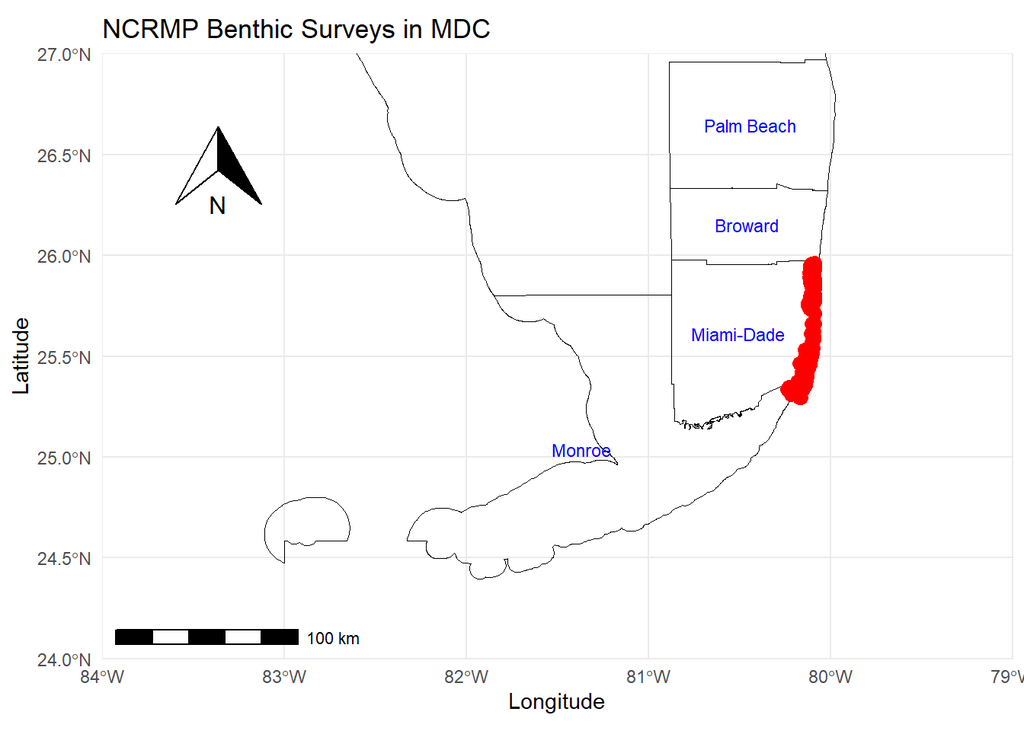

```r
# Add county names
centroids$NAME <- south_florida_counties$NAME

# Convert df to an sf object
mdcBiscBenthic_sf <- st_as_sf(mdcBiscBenthic, coords = c("LON_DEGREES", "LAT_DEGREES"), crs = 4326)

# Plot
mdcBiscBenthicMap = ggplot() +
# Add the outline of Florida
geom_sf(data = fl_state, fill = NA, color = "black") +
geom_sf(data = south_florida_counties, fill = NA, color = "black") +
  geom_sf(data = mdcBiscBenthic_sf, color = "red", size = 3) +
  geom_text(data = centroids, aes(x = X, y = Y, label = NAME), size = 3, color = "blue") +
  labs(title = "NCRMP Benthic Surveys in MDC",
       x = "Longitude",
       y = "Latitude") +
   coord_sf(xlim = c(-84, -79), ylim = c(24, 27), expand = FALSE) +  # Set the bounding box for the map
  annotation_scale(location = "bl") +
    annotation_north_arrow(location = "tl",  # Place north arrow in the top-left corner
                         which_north = "true",
                         pad_x = unit(0.5, "in"),
                         pad_y = unit(0.5, "in"))+
  theme_minimal()
mdcBiscBenthicMap
```

###Demo

```r
#Can I join allNcrmpDemo, preNcrmpScreamDemo, drmSefcriDemo1422, drmFlkDemo1422? Let's look at their column names:
cols_allNcrmpDemo = names(allNcrmpDemo)
if (!is.character(cols_allNcrmpDemo)) cols_allNcrmpDemo <- as.character(cols_allNcrmpDemo)

cols_preNcrmpScreamDemo = names(preNcrmpScreamDemo)
if (!is.character(cols_preNcrmpScreamDemo)) cols_preNcrmpScreamDemo <- as.character(cols_preNcrmpScreamDemo)

cols_drmSefcriDemo1422 = names(drmSefcriDemo1422)
if (!is.character(cols_drmSefcriDemo1422)) cols_drmSefcriDemo1422 <-
as.character(cols_drmSefcriDemo1422)

cols_drmFlkDemo1422 = names(drmFlkDemo1422)
if (!is.character(cols_drmFlkDemo1422)) cols_drmFlkDemo1422 <-
  as.character(cols_drmFlkDemo1422)

#What data columns do they have in common?
common_cols <- Reduce(intersect, list(cols_allNcrmpDemo, cols_preNcrmpScreamDemo, cols_drmSefcriDemo1422, cols_drmFlkDemo1422))
common_cols
```

```
##  [1] "REGION"              "PRIMARY_SAMPLE_UNIT" "STATION_NR"
##  [4] "YEAR"                "MONTH"               "DAY"
##  [7] "HABITAT_CD"          "STRAT"               "RUGOSITY_CD"
## [10] "WTD_RUG"             "LAT_DEGREES"         "LON_DEGREES"
## [13] "MAPGRID_NR"          "SUB_REGION_NAME"     "SUB_REGION_NR"
## [16] "ZONE_NAME"           "ZONE_NR"             "MPA_NAME"
## [19] "MPA_NR"              "ADMIN"               "PROT"
## [22] "DEPTH_STRAT"         "MIN_DEPTH"           "MAX_DEPTH"
## [25] "METERS_COMPLETED"    "SPECIES_CD"          "SPECIES_NAME"
## [28] "N"                   "JUV"                 "MAX_DIAMETER"
## [31] "PERP_DIAMETER"       "HEIGHT"              "OLD_MORT"
## [34] "RECENT_MORT"         "BLEACH_CONDITION"    "DISEASE"
## [37] "SURVEY"
```

```r
#Filter out all but the columns in common
allNcrmpDemo_common <- allNcrmpDemo %>% select(all_of(common_cols))
preNcrmpScreamDemo_common <- preNcrmpScreamDemo %>% select(all_of(common_cols))
drmSefcriDemo1422_common <- drmSefcriDemo1422 %>% select(all_of(common_cols))
drmFlkDemo1422_common <- drmFlkDemo1422 %>% select(all_of(common_cols))

str(allNcrmpDemo_common)
```

```
## 'data.frame':    298044 obs. of  37 variables:
##  $ REGION             : chr  "SEFCRI" "SEFCRI" "SEFCRI" "SEFCRI" ...
##  $ PRIMARY_SAMPLE_UNIT: num  3127 3127 3157 3157 3163 ...
##  $ STATION_NR         : num  1 2 1 2 1 2 1 2 1 2 ...
##  $ YEAR               : num  2014 2014 2014 2014 2014 ...
##  $ MONTH              : num  9 9 9 9 9 9 9 9 9 9 ...
##  $ DAY                : int  11 11 11 11 11 11 12 12 12 12 ...
##  $ HABITAT_CD         : chr  "LIRM" "LIRM" "LIRM" "LIRM" ...
##  $ STRAT              : chr  "MIDR0" "MIDR0" "MIDR1" "MIDR1" ...
##  $ RUGOSITY_CD        : num  0 0 1 1 1 1 1 1 0 0 ...
##  $ WTD_RUG            : num  0.29 0.217 0.277 0.297 0.23 ...
##  $ LAT_DEGREES        : num  26.2 26.2 26.2 26.2 26.1 ...
##  $ LON_DEGREES        : num  -80.1 -80.1 -80.1 -80.1 -80.1 ...
##  $ MAPGRID_NR         : chr  "352368" "352368" "355646" "355646" ...
##  $ SUB_REGION_NAME    : chr  "Broward-Miami" "Broward-Miami" "Broward-Miami" "Broward-Miami" ...
```

[output cut: 23 more lines]

```r
allNcrmpDemo_common$PRIMARY_SAMPLE_UNIT <- as.character(allNcrmpDemo_common$PRIMARY_SAMPLE_UNIT)
allNcrmpDemo_common$MAPGRID_NR <- as.integer(allNcrmpDemo_common$MAPGRID_NR)
str(preNcrmpScreamDemo_common)
```

```
## 'data.frame':    381276 obs. of  37 variables:
##  $ REGION             : chr  "FLK" "FLK" "FLK" "FLK" ...
##  $ PRIMARY_SAMPLE_UNIT: chr  "940763" "1010769" "1010769" "1010769" ...
##  $ STATION_NR         : int  3 1 2 3 3 3 4 1 2 2 ...
##  $ YEAR               : int  2005 2005 2005 2005 2005 2005 2005 2005 2005 2005 ...
##  $ MONTH              : int  NA NA NA NA NA NA NA NA NA NA ...
##  $ DAY                : int  NA NA NA NA NA NA NA NA NA NA ...
##  $ HABITAT_CD         : chr  "ISOL_MR" "ISOL_LR" "ISOL_LR" "ISOL_LR" ...
##  $ STRAT              : chr  "MCPR" "MCPR" "MCPR" "MCPR" ...
##  $ RUGOSITY_CD        : int  NA NA NA NA NA NA NA NA NA NA ...
##  $ WTD_RUG            : logi  NA NA NA NA NA NA ...
##  $ LAT_DEGREES        : num  24.5 24.5 24.5 24.5 24.5 ...
##  $ LON_DEGREES        : num  -81.6 -81.6 -81.6 -81.6 -81.6 ...
##  $ MAPGRID_NR         : int  1054694 1090456 1090456 1090456 1090456 1090456 1090456 1096000 1096000 1096000 ...
##  $ SUB_REGION_NAME    : chr  "Lower Keys" "Lower Keys" "Lower Keys" "Lower Keys" ...
```

[output cut: 23 more lines]

```r
str(drmSefcriDemo1422_common)
```

```
## 'data.frame':    53390 obs. of  37 variables:
##  $ REGION             : chr  "SEFCRI" "SEFCRI" "SEFCRI" "SEFCRI" ...
##  $ PRIMARY_SAMPLE_UNIT: chr  "W1000" "W1000" "W1002" "W1002" ...
##  $ STATION_NR         : int  10486 10488 10490 10492 10498 2 10502 10506 10509 10513 ...
##  $ YEAR               : int  2022 2022 2022 2022 2022 2022 2022 2022 2022 2022 ...
##  $ MONTH              : int  8 8 8 8 8 8 8 8 8 8 ...
##  $ DAY                : int  15 15 15 15 15 15 15 15 15 15 ...
##  $ HABITAT_CD         : chr  "RGSH" "RGSH" "RGSH" "RGSH" ...
##  $ STRAT              : chr  "NEAR0" "NEAR0" "NEAR0" "NEAR0" ...
##  $ RUGOSITY_CD        : int  0 0 0 0 0 0 0 0 0 0 ...
##  $ WTD_RUG            : logi  NA NA NA NA NA NA ...
##  $ LAT_DEGREES        : num  27.1 27.1 27.1 27.1 27.1 ...
##  $ LON_DEGREES        : num  -80.1 -80.1 -80.1 -80.1 -80.1 ...
##  $ MAPGRID_NR         : int  63025 63025 67614 67614 89264 89264 93875 93875 94519 94519 ...
##  $ SUB_REGION_NAME    : chr  "Martin" "Martin" "Martin" "Martin" ...
```

[output cut: 23 more lines]

```r
str(drmFlkDemo1422_common)
```

```
## 'data.frame':    145971 obs. of  37 variables:
##  $ REGION             : chr  "FLK" "FLK" "FLK" "FLK" ...
##  $ PRIMARY_SAMPLE_UNIT: chr  "U1169" "U1169" "U1175" "U1175" ...
##  $ STATION_NR         : int  8209 8241 8255 8265 8276 8286 8347 8381 8343 8385 ...
##  $ YEAR               : int  2020 2020 2020 2020 2020 2020 2020 2020 2020 2020 ...
##  $ MONTH              : int  9 9 9 9 9 9 10 10 10 10 ...
##  $ DAY                : int  29 29 19 19 18 18 16 16 16 16 ...
##  $ HABITAT_CD         : chr  "ISOL_MR" "ISOL_MR" "SPGR_HR" "SPGR_HR" ...
##  $ STRAT              : chr  "CS12" "CS12" "CS12" "CS12" ...
##  $ RUGOSITY_CD        : logi  NA NA NA NA NA NA ...
##  $ WTD_RUG            : logi  NA NA NA NA NA NA ...
##  $ LAT_DEGREES        : num  25.7 25.7 25.6 25.6 25.5 ...
##  $ LON_DEGREES        : num  -80.1 -80.1 -80.1 -80.1 -80.1 ...
##  $ MAPGRID_NR         : int  4139407 4139407 4084136 4084136 4050283 4050283 3891712 3891712 3868355 3868355 ...
##  $ SUB_REGION_NAME    : chr  "Biscayne" "Biscayne" "Biscayne" "Biscayne" ...
```

[output cut: 23 more lines]

```r
#Combine dataframes by their common columns:
allDemo <- bind_rows(allNcrmpDemo_common, preNcrmpScreamDemo_common, drmSefcriDemo1422_common, drmFlkDemo1422_common)
unique(allDemo$SUB_REGION_NAME)
```

```
##  [1] "Broward-Miami"             "Deerfield"
##  [3] "South Palm Beach"          "North Palm Beach"
##  [5] "Martin"                    "Biscayne"
##  [7] "Upper Keys"                "Mid-Upper Keys Transition"
##  [9] "Middle Keys"               "Lower Keys"
## [11] "Marquesas"                 "Marquesas-Tortugas Trans"
## [13] "Tortugas--Dry Tortugas NP" "Tortugas--Tortugas Bank"
## [15] "Tortugas--Unmapped"        "STT"
## [17] "STJ"                       "SLRK"
## [19] "MSR"                       "ESTX"
## [21] "LANG"                      "NWSTX"
## [23] "SSTX"                      "EDGE"
## [25] "SW"                        "E"
## [27] "N"                         "EPRICO"
## [29] "NPRICO"                    "SWPRICO"
## [31] "EB"                        "WB"
## [33] NA
```

```r
unique(allDemo$SURVEY)
```

```
## [1] "NCRMP"  "SCREAM" "DRM"
```

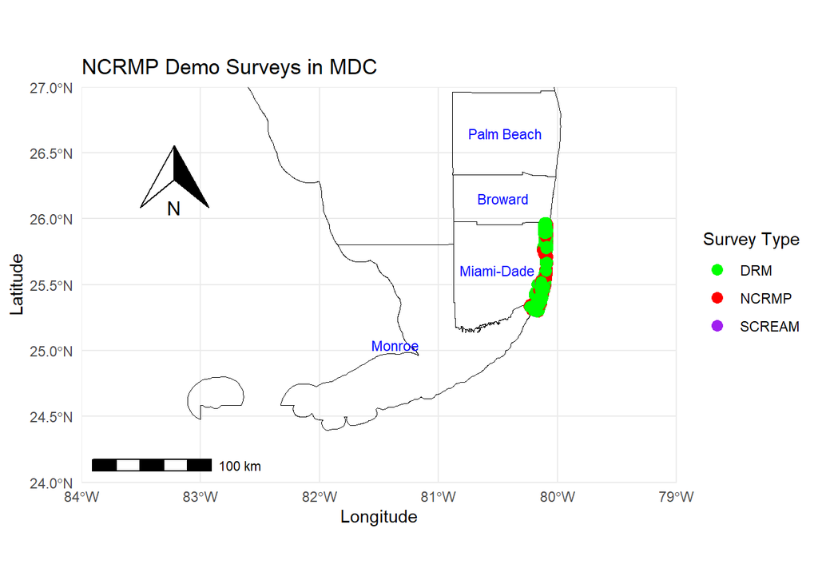

```r
#Filter the demo data to just Biscayne and Broward-Miami
mdcBiscDemo <- allDemo %>%
  mutate(SURVEY_ID = paste(PRIMARY_SAMPLE_UNIT, STATION_NR, sep = "-")) %>%
filter(SUB_REGION_NAME %in% c("Biscayne", "Broward-Miami")) %>%
  filter(LAT_DEGREES < 25.97) %>%
  mutate(
    LAT_DEGREES = round(LAT_DEGREES, 5),
    LON_DEGREES = round(LON_DEGREES, 5)
  ) %>%
  arrange(YEAR, MONTH, DAY, REGION, PRIMARY_SAMPLE_UNIT, STATION_NR) %>%
  #Can remove all the actual demo data
  select(-RUGOSITY_CD, -WTD_RUG, -SPECIES_CD, -SPECIES_NAME, -N, -JUV, -MAX_DIAMETER, -PERP_DIAMETER, -HEIGHT, -OLD_MORT, -RECENT_MORT, -BLEACH_CONDITION, -DISEASE)%>%
  distinct(REGION,PRIMARY_SAMPLE_UNIT,STATION_NR,YEAR,MONTH,DAY,HABITAT_CD,STRAT,MAPGRID_NR,SUB_REGION_NAME,SUB_REGION_NR,ZONE_NAME,ZONE_NR,MPA_NAME,MPA_NR,ADMIN,PROT,DEPTH_STRAT,MIN_DEPTH,MAX_DEPTH,METERS_COMPLETED,SURVEY, LAT_DEGREES, LON_DEGREES, SURVEY_ID)

#write.csv(mdcBiscDemo, file = "./data/mdcBiscDemoSurveys.csv", row.names = FALSE)

# region_survey_summary <- allDemo %>%
#   group_by(SUB_REGION_NAME) %>%
#   summarize(SURVEY_TYPES = list(unique(SURVEY)), .groups = 'drop')
#
# mdcBisc_survey_summary <- mdcBiscDemo %>%
#   group_by(SUB_REGION_NAME) %>%
#   summarize(SURVEY_TYPES = list(unique(SURVEY)), .groups = 'drop')

#Make a map of the demo surveys
# Load Florida counties shapefile
fl_counties <- counties(state = "FL", year = 2021)

# Filter for the specific South Florida counties
south_florida_counties <- fl_counties %>%
  filter(NAME %in% c("Miami-Dade", "Broward", "Palm Beach", "Monroe"))
#Add state boundary
fl_state <- states(year = 2021) %>%
  filter(STUSPS == "FL")

# Calculate centroids for county labels
centroids <- south_florida_counties %>%
  st_centroid() %>%
  st_coordinates() %>%
  as.data.frame()
# Add county names
centroids$NAME <- south_florida_counties$NAME

# Convert df to an sf object
mdcBiscDemo_sf <- st_as_sf(mdcBiscDemo, coords = c("LON_DEGREES", "LAT_DEGREES"), crs = 4326)

mdcBiscDemoMap = ggplot() +
# Add the outline of Florida
geom_sf(data = fl_state, fill = NA, color = "black") +
geom_sf(data = south_florida_counties, fill = NA, color = "black") +
  geom_sf(data = mdcBiscDemo_sf, aes(color = SURVEY), size = 3) +
  geom_text(data = centroids, aes(x = X, y = Y, label = NAME), size = 3, color = "blue") +
  labs(title = "NCRMP Demo Surveys in MDC",
       x = "Longitude",
       y = "Latitude",
       color = "Survey Type") +
   coord_sf(xlim = c(-84, -79), ylim = c(24, 27), expand = FALSE) +  # Set the bounding box for the map
  annotation_scale(location = "bl") +
    annotation_north_arrow(location = "tl",  # Place north arrow in the top-left corner
                         which_north = "true",
                         pad_x = unit(0.5, "in"),
                         pad_y = unit(0.5, "in"))+
 scale_color_manual(values = c("DRM" = "green",
                                "NCRMP" = "red",
                                "SCREAM" = "purple"))+
  theme_minimal()
mdcBiscDemoMap
```

##Number of Surveys ** What is the survey # in each (BISC + MDC, BISC) by year for NCRMP surveys, DRM surveys, and combined surveys? 1. For each year separately 2. Pre-2015 years combined 3. And post-2015 years combined: ###Benthic

```r
# Calculate the number of unique LPI surveys per year
mdcBiscBenthicSurveys <- mdcBiscBenthic %>%
# Group by YEAR
group_by(YEAR) %>%
# Count unique combinations of PRIMARY_SAMPLE_UNIT and STATION_NR
  summarise(num_surveys = n_distinct(paste(PRIMARY_SAMPLE_UNIT, STATION_NR, sep = "_")), .groups = 'drop')%>%
  mutate(YEAR = as.character(YEAR))  # Ensure YEAR is character

# View the results
print(mdcBiscBenthicSurveys)
```

```
## # A tibble: 7 × 2
##   YEAR  num_surveys
##   <chr>       <int>
## 1 2014           20
## 2 2015           86
## 3 2016           26
## 4 2018           43
## 5 2020           17
## 6 2021           12
## 7 2022           50
```

```r
# Calculate total surveys
total_surveysBenthic <- mdcBiscBenthicSurveys %>%
  summarise(YEAR = "Total", num_surveys = sum(num_surveys))%>%
  mutate(YEAR = as.character(YEAR))  # Ensure YEAR is character

# Calculate total surveys for 2015 and earlier
total_surveys_before_2016Benthic <- mdcBiscBenthicSurveys %>%
  filter(YEAR <= 2015) %>%
  summarise(YEAR = "Total pre-2015", num_surveys = sum(num_surveys))%>%
  mutate(YEAR = as.character(YEAR))  # Ensure YEAR is character

# Calculate total surveys for 2016 and later
total_surveys_from_2016Benthic <- mdcBiscBenthicSurveys %>%
  filter(YEAR >= 2016) %>%
  summarise(YEAR = "Total post-2015", num_surveys = sum(num_surveys))%>%
  mutate(YEAR = as.character(YEAR))  # Ensure YEAR is character

# Combine all results
mdcBiscBenthicSurveysTotal <- bind_rows(mdcBiscBenthicSurveys, total_surveysBenthic, total_surveys_before_2016Benthic, total_surveys_from_2016Benthic)

# Print the combined results
mdcBiscBenthicSurveysTotal
```

```
## # A tibble: 10 × 2
##    YEAR            num_surveys
##    <chr>                 <int>
##  1 2014                     20
##  2 2015                     86
##  3 2016                     26
##  4 2018                     43
##  5 2020                     17
##  6 2021                     12
##  7 2022                     50
##  8 Total                   254
##  9 Total pre-2015          106
## 10 Total post-2015         148
```

```r
mdcBiscBenthicSurveysTotal <- mdcBiscBenthicSurveysTotal %>%
  rename("lpiSurveys" = num_surveys)
mdcBiscBenthicSurveysTotal
```

```
## # A tibble: 10 × 2
##    YEAR            lpiSurveys
##    <chr>                <int>
##  1 2014                    20
##  2 2015                    86
##  3 2016                    26
##  4 2018                    43
##  5 2020                    17
##  6 2021                    12
##  7 2022                    50
##  8 Total                  254
##  9 Total pre-2015         106
## 10 Total post-2015        148
```

###Demo

```r
# Calculate the number of unique Demo surveys per year
mdcBiscDemoSurveys <- mdcBiscDemo %>%
# Group by YEAR
group_by(YEAR, SURVEY) %>%
# Count unique combinations of PRIMARY_SAMPLE_UNIT and STATION_NR
summarize(Count = n(), .groups = "drop") %>%
pivot_wider(names_from = SURVEY, values_from = Count, values_fill = list(Count = 0)) %>%
  mutate(Total_Surveys = rowSums(select(., starts_with("SCREAM"):starts_with("DRM")), na.rm = TRUE))

# Add total rows for 2015 and earlier, 2016 and later, and overall
totals_df <- mdcBiscDemo %>%
  mutate(Period = if_else(YEAR <= 2015, "2015 and earlier", "2016 and later")) %>%
  group_by(Period, SURVEY) %>%
  summarize(Count = n(), .groups = "drop") %>%
  pivot_wider(names_from = SURVEY, values_from = Count, values_fill = list(Count = 0)) %>%
  mutate(Total_Surveys = rowSums(across(c(SCREAM, NCRMP, DRM)), na.rm = TRUE)) %>%
  bind_rows(
    mdcBiscDemo %>%
      group_by(SURVEY) %>%
      summarize(Count = n(), .groups = "drop") %>%
      pivot_wider(names_from = SURVEY, values_from = Count, values_fill = list(Count = 0)) %>%
      mutate(Period = "Overall", Total_Surveys = rowSums(across(c(SCREAM, NCRMP, DRM)), na.rm = TRUE))
  ) %>%
  select(YEAR = Period, everything())

# Combine original summary with totals
# Convert YEAR to character in mdcBiscDemoSurveys
mdcBiscDemoSurveys <- mdcBiscDemoSurveys %>%
  mutate(YEAR = as.character(YEAR))

# Convert YEAR to character in totals_df
totals_df <- totals_df %>%
  mutate(YEAR = as.character(YEAR))

mdcBiscDemoSurveys <- bind_rows(mdcBiscDemoSurveys, totals_df)
mdcBiscDemoSurveys
```

```
## # A tibble: 22 × 5
##    YEAR  SCREAM   DRM NCRMP Total_Surveys
##    <chr>  <int> <int> <int>         <dbl>
##  1 2002      28     0     0            28
##  2 2005     121    66     0           187
##  3 2006       0   116     0           116
##  4 2007       0    87     0            87
##  5 2008       0    83     0            83
##  6 2009       0   140     0           140
##  7 2010       0   109     0           109
##  8 2011       0   146     0           146
##  9 2012      34   100     0           134
## 10 2013       0    62     0            62
## # ℹ 12 more rows
```